# Analysis of Blood Pressure Measurements

Sandeep Dutta

June 30, 2016

## Synopsis

The goal of this study is to study the effects of different hypertension reducing medications on the observed blood pressure readings obtained from a subject. It is intended to see which medication has the most effect on lowering blood pressure and if there is any statistically significant difference between the medication groups.

## Data Collection

The readings were obtained from an automatic cuff BP machine Omron model BP760N. The rreadings were obtained during various times of the day - generally in the morning after waking up, in the afternoon, in the evening and at night.

At least three readings were taken at one minute intervals during each observation time and the Systolic, Diastolic pressure readings in mmHg and pulse rate in beats per minute was recorded. In addition the weight of the person was also recorded once daily right after waking up in the morning.

The subject was given five different combinations of hypertension reducing medications. The subject was on a particular medication for about 2 weeks and then switched to the next one. Finally the last medication was continued for a longer period to see whether the effect was stable.

## Results

Here is a summary of all the readings for each medication group. The mean and standard deviation of Systolic and Diastolic BP readings are shown here grouped by each medication. The mean systolic BP value dropped from $146\pm7.1$ for treatment A to $126\pm7.1$ for treatment E, and correspondingly the mean diastolic BP dropped from $97\pm5.2$ to $82\pm4.8$.

|  | Systolic Mean | Systolic SD | Diastolic Mean | Diastolic SD |
| --- | --- | --- | --- | --- |
| A | 146 | 7.12 | 97.5 | 5.15 |
| B | 143 | 5.64 | 97.7 | 3.86 |
| C | 138 | 8.00 | 91.5 | 5.60 |
| D | 133 | 6.80 | 88.0 | 4.32 |
| E | 126 | 7.16 | 82.6 | 4.85 |

Next we visualize the individual Systolic and Diastolic pressure readings as a scatter plot. Each point plotted corresponds to a reading taken and the readings are shown such that the day of the reading is along the x-axis. The plotted points are color coded by which medication was being taken by the subject during that time period.

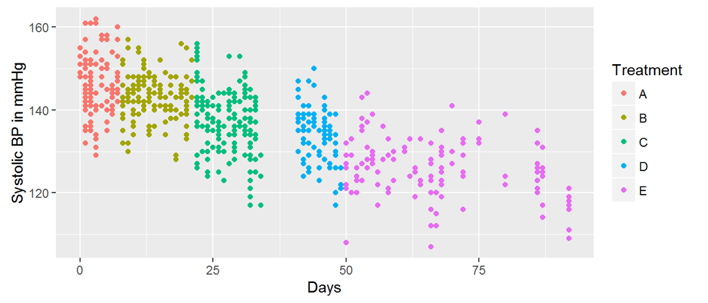

Fig 1: Distribution of Systolic BP readings

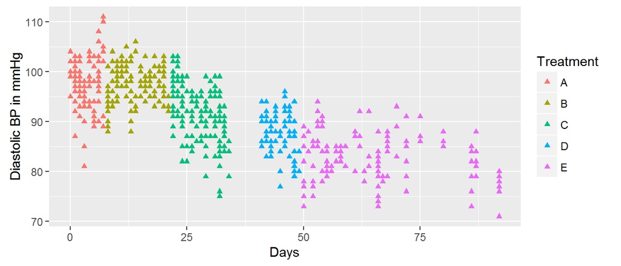

Fig 2: Distribution of Diastolic BP readings

The next two plots shows the box plot of the Systolic and Diastolic BP readings and it is again color coded based on the medication group. The boxplot as you know gives a visual impression of the inter quartile distribution and any outliers in the readings. The box plot for the Systolic BP shows that the readings were highest for group A and progressively lower with other groups with the lowest being for the E group while the diastolic BP readings for the A and B groups were similar but a clear drop is seen with the other groups.

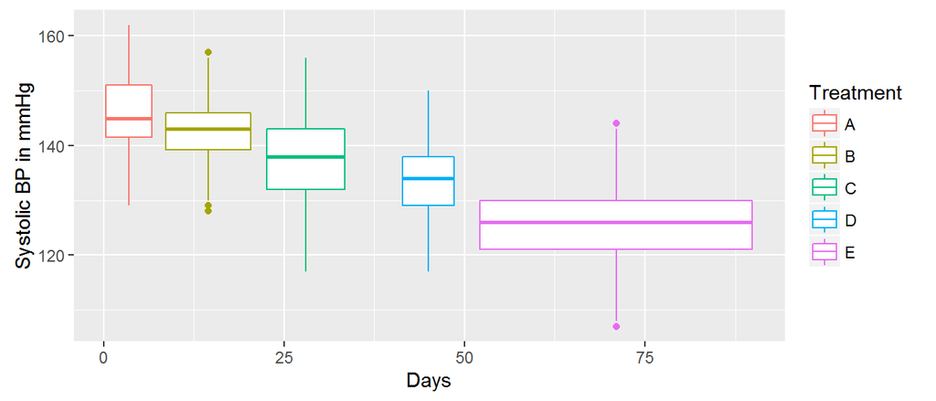

Fig 3: Boxplot summary of Systolic BP readings

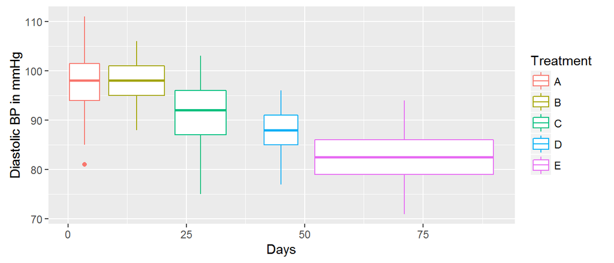

Fig 4: Boxplot summary of Diastolic BP readings

Having observed a clear drop in the readings with newer medication treatments, analysis is next performed to see what percentage of the individual readings fall within the normal BP thresholds adopted by the medical community. Literaure and guidelines suggest a reading below 135/85 to be considered a **normal** reading. Individual readings are categorized to to be **Normal, Mild** and **High** based on whether both Systolic and Diastolic are below the threshold, one of the two is above its threshold or both are above threshold.

The frequency distribution of the readings in different categories and the percentage distribution within each treatment are shown below

```
##           A   B   C   D   E
##
## High    102 123 102  39  10
## Mild      4  11  40  32  44
## Normal    1   0  14  17  76
```

```
##
##                A       B       C       D       E
##   High   0.95327 0.91791 0.65385 0.44318 0.07692
##   Mild   0.03738 0.08209 0.25641 0.36364 0.33846
##   Normal 0.00935 0.00000 0.08974 0.19318 0.58462
```

Now the distribution of the categories of the readings are looked at visually using a bar chart and pie chart that shows the progressive increase in Normal readings with Treatment. The High readings are indicated with red, Mild with yellow and the normal reading with green.

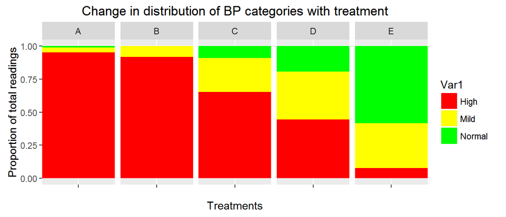

Fig 5: Variation in category of BP readings with treatments

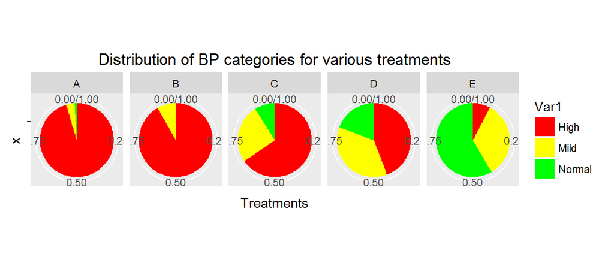

Fig 6: Piechart showing change in BP reading category with treatments

It is very clear from the above results and figures 5 and 6, that the percentage of Normal readings have increased significantly with treatments and the High BP readings have dropped by a huge proportion under treatment E. The Normal and Mild BP readings constitute more than **92%** of the total readings under Treatment E.

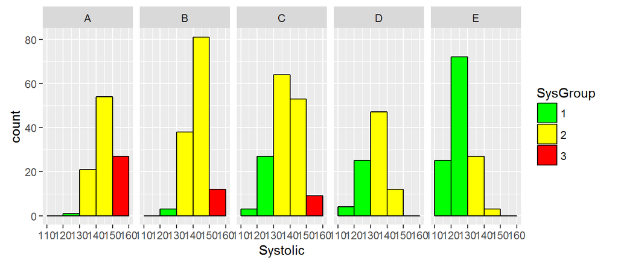

Fig 7: Change in Systolic BP reading with Treatment

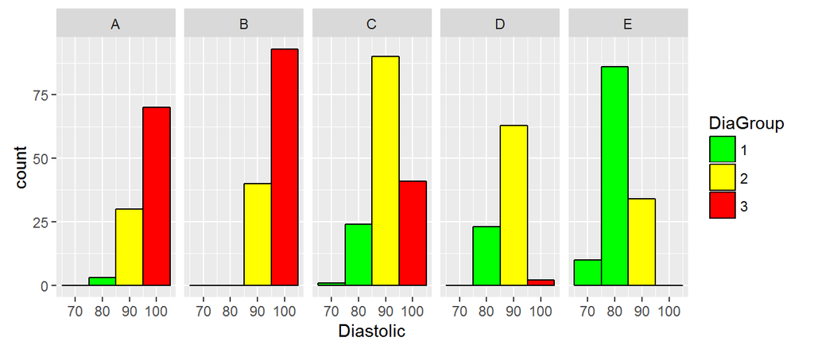

Fig 8: Change in Diastolic BP reading with Treatment

In figures 7 and 8, the change in levels of Systolic and Diastolic BP readings are looked at individually against each treatment. In the histograms, the levels of the readings are color coded. For example, any systolic reading below 130 is indicated as green, between 130 and 150 as yellow and above 150 in red. It is clear from Fig 7. that the level of systolic readings is much lower in Treatment E compared to Treatments A and B, indicated by the disappearance of the red bars and increase in green bars. However the impact is even more drastic for Diastolic readigs as shown in Fig. 8. The high diastolic readings indicated by red bars which were prominent under A, B and C, is non-existent under E, whereas the low reading indicated by green bar is most common.

## Statistical Analysis

Next statistical analysis was performed to see whether the blood pressure measurements are different due to the different medications. Histograms of the Systolic and Diastolic BP readings are plotted as below to see if the the measurements can be considered to be following a normal distribution.

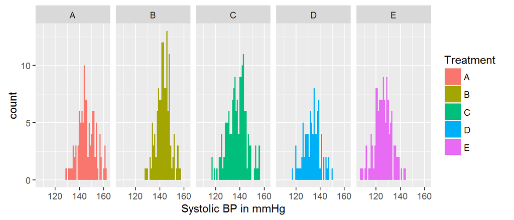

Fig 9: Distribution of Systolic BP readings

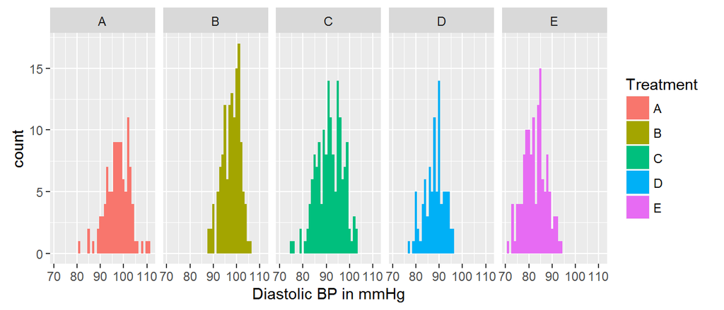

Fig 10: Distribution of Diastolic BP readings

The Alternate Hypothesis considered is that the measurements for the different medication groups are different.

The ANOVA for Systolic BP returns the following results:

```
##                   Df Sum Sq Mean Sq F value              Pr(>F)
## bpdata$Treatment   4  31475    7869     159 <0.0000000000000002 ***
## Residuals        610  30178      49
## ---
## Signif. codes:  0 '***' 0.001 '**' 0.01 '*' 0.05 '.' 0.1 ' ' 1
```

Similarly the ANOVA analysis of diastolic BP is shown below:

```
##                   Df Sum Sq Mean Sq F value              Pr(>F)
## bpdata$Treatment   4  20404    5101     217 <0.0000000000000002 ***
## Residuals        610  14325      23
## ---
## Signif. codes:  0 '***' 0.001 '**' 0.01 '*' 0.05 '.' 0.1 ' ' 1
```

The P-values from the ANOVA analysis show that the means of the readings under different medications are different. Now to find more information about the differences, TukeyHSD test is performed to do a post hoc pair comparison test.

```
##   Tukey multiple comparisons of means
##     95% family-wise confidence level
##
## Fit: aov(formula = bpdata$Systolic ~ bpdata$Treatment)
##
## $`bpdata$Treatment`
##       diff    lwr     upr p adj
## B-A  -3.09  -5.58  -0.591 0.007
## C-A  -8.38 -10.79  -5.960 0.000
## D-A -12.60 -15.37  -9.836 0.000
## E-A -20.41 -22.92 -17.897 0.000
## C-B  -5.29  -7.56  -3.023 0.000
## D-B  -9.52 -12.16  -6.878 0.000
## E-B -17.32 -19.69 -14.954 0.000
## D-C  -4.23  -6.79  -1.664 0.000
## E-C -12.03 -14.32  -9.748 0.000
## E-D  -7.80 -10.46  -5.148 0.000
```

```
##   Tukey multiple comparisons of means
##     95% family-wise confidence level
##
## Fit: aov(formula = bpdata$Diastolic ~ bpdata$Treatment)
##
## $`bpdata$Treatment`
##        diff    lwr    upr p adj
## B-A   0.197  -1.52   1.92 0.998
## C-A  -6.036  -7.70  -4.37 0.000
## D-A  -9.565 -11.47  -7.66 0.000
## E-A -14.896 -16.63 -13.17 0.000
## C-B  -6.232  -7.79  -4.67 0.000
## D-B  -9.762 -11.58  -7.94 0.000
## E-B -15.093 -16.72 -13.46 0.000
## D-C  -3.529  -5.30  -1.76 0.000
## E-C  -8.860 -10.43  -7.29 0.000
## E-D  -5.331  -7.16  -3.50 0.000
```

The results show that for Systolic BP, all groups are different from each other at a p<0.05 level whereas for Diastolic BP, only A and B are not different.

## Trends

The systolic and diastolic BP readings are plotted to find if there are any trends that can be observed in the readings. It is clear that the two readings are correlated for all the medicine groups, meaning a higher value of diastolic BP always corresponds to a higher value of the systolic BP as indicated by the slope of the fitted lines. The slopes of all treatment lines are similar except for treatment B where the diastolic values were slightly higher for corresponding systolic values.

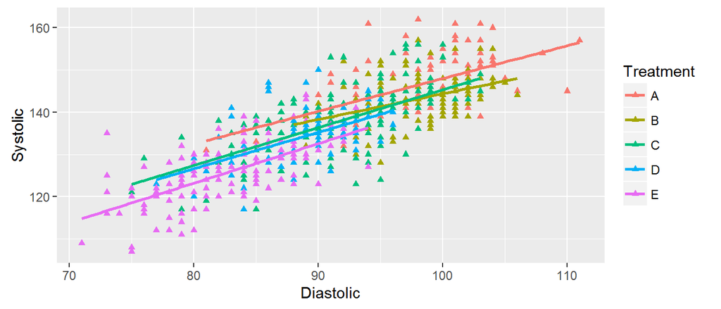

We also look at the trend in Systolic and Diastolic BP readings over the number of days in the treatment. Starting with Treatment C, we can clearly see a downward trend in the values of both Systolic and Diastolic BP as the subject spends more days in that treatment. The Diastolic BP for treatments A and B showed a trend to be higher with increasing number of days in these treatments.

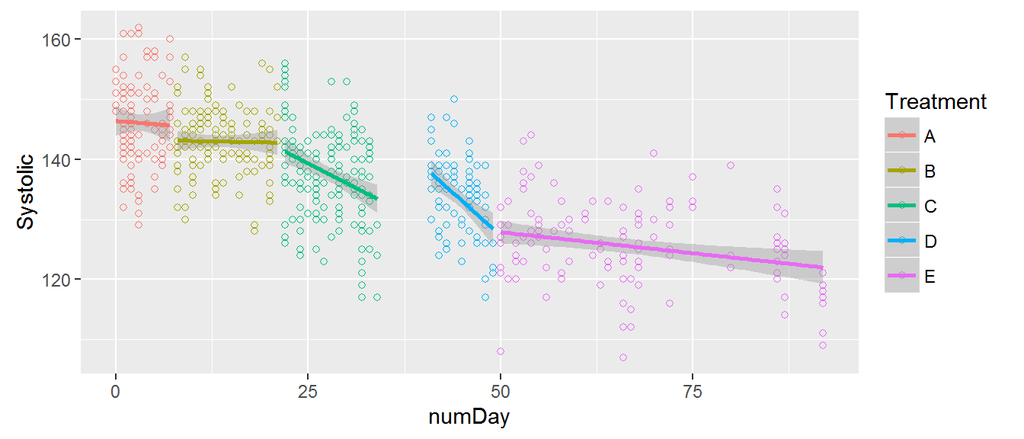

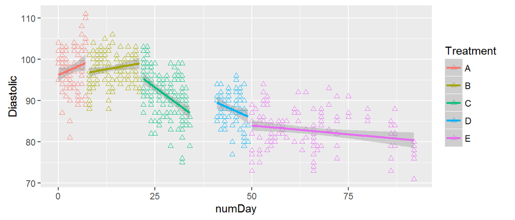

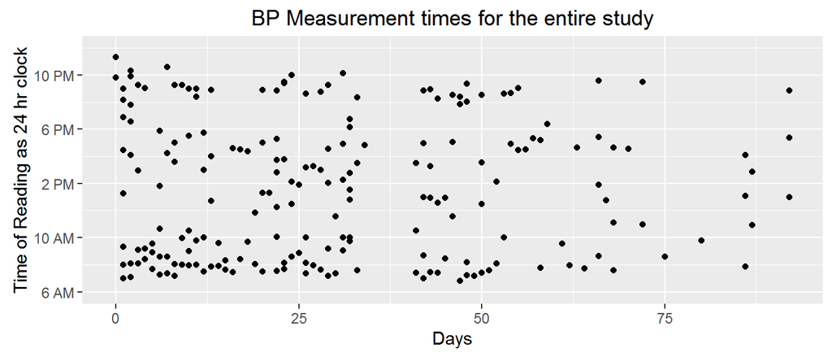

Next the mean of the BP readings for all the treatments at each period of the day are determined and tabulated below. There seems to be no pattern observed for the period of the day when the readings were taken.

|  | Systolic Mean | Systolic SD | Diastolic Mean | Diastolic SD |
| --- | --- | --- | --- | --- |
| Afternoon | 136 | 11.98 | 89.2 | 8.46 |
| Evening | 136 | 9.63 | 89.4 | 7.14 |
| Morning | 138 | 8.58 | 93.9 | 6.53 |
| Night | 139 | 10.74 | 91.9 | 7.53 |